# Oct-27-BDA-Seminar

Hyogo Shiiiii

**0. Acknowlegement** 99.9% of my work is influenced by Yuan’s advice. I appreciate all of his comments to do this.

## Data Description

```r
library(dplyr)
library(rstan)
library(loo)
```

```r
library(bayesplot)
library(kableExtra)
options(mc.cores = parallel::detectCores()-1)

dat <- read.table("https://drive.google.com/uc?export=download&id=1SY0vPf9TVz_jo7qtq6wuFuxmL3aqNUda",header=T)
head(dat)
```

|  | home | favorite | underdog | spread | favorite.name | underdog.name | week |
| --- | --- | --- | --- | --- | --- | --- | --- |
| 1 | 1 | 21 | 13 | 2.0 | TB | MIN | 1 |
| 2 | 1 | 27 | 0 | 9.5 | ATL | NO | 1 |
| 3 | 1 | 31 | 0 | 4.0 | BUF | NYJ | 1 |
| 4 | 1 | 9 | 16 | 4.0 | CHI | GB | 1 |
| 5 | 1 | 27 | 21 | 4.5 | CIN | SEA | 1 |
| 6 | 0 | 26 | 10 | 2.0 | DAL | WAS | 1 |

```r
dim(dat)
```

```
## [1] 2240    7
```

- home: A binary variable indicating the venue of the game for the favorite team. If home is 1, then the favorite team played at their home stadium. If home is 0, then they played away.
- favorite: The number of points scored by the team that was favored to win (according to pre-game odds or expert predictions).
- underdog: The number of points scored by the team that was expected to lose or was not the favored team.
- spread: The point spread set by bookmakers. This is an estimate of the expected point difference between the favorite and the underdog.
- favorite.name: The name (or abbreviation) of the team that was favored to win.
- underdog.name: The name (or abbreviation) of the team that was the underdog.
- week: The week of the football season in which the game took place.

##Split the data into training data and test data

```r
# Set the random seed for reproducibility
set.seed(123)

# Generate a random sample of 2000 indices for the training data
ind <- sample(1:2240, 2000)

# Create the training dataset by selecting rows based on the random indices
train_data <- dat[ind,]

# Create the test dataset by excluding the rows used for training
test_data <- dat[-ind,]
```

## Visualization of data

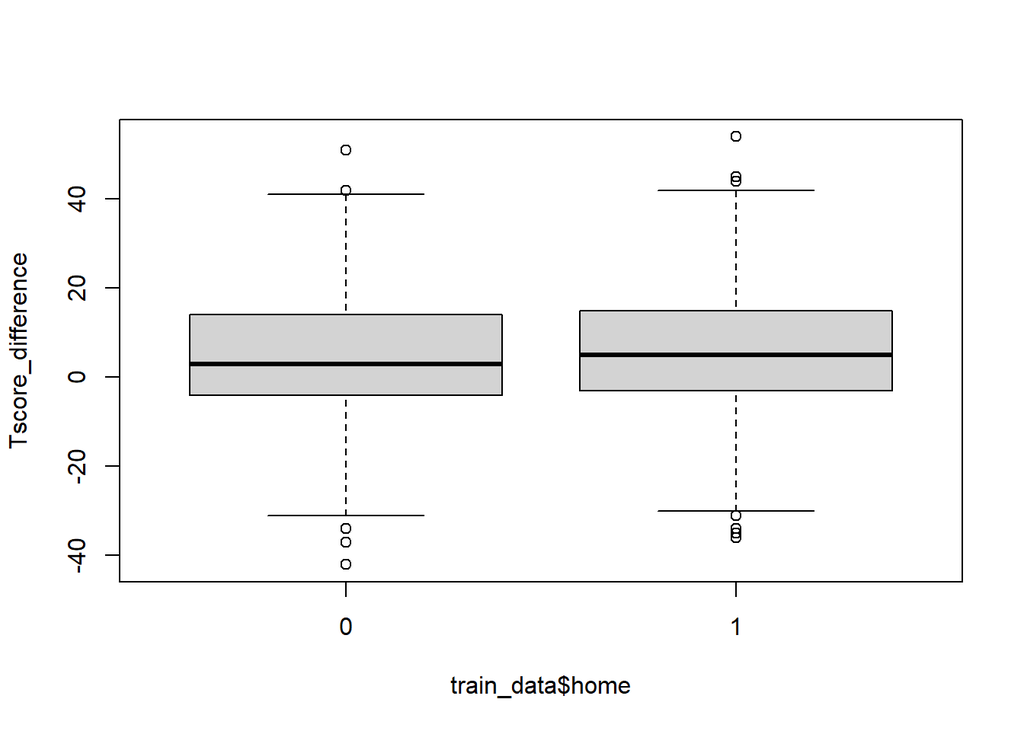

```r
Tscore_difference <- train_data$favorite - train_data$underdog
Tspread <- train_data$spread

boxplot(Tscore_difference~train_data$home)
```

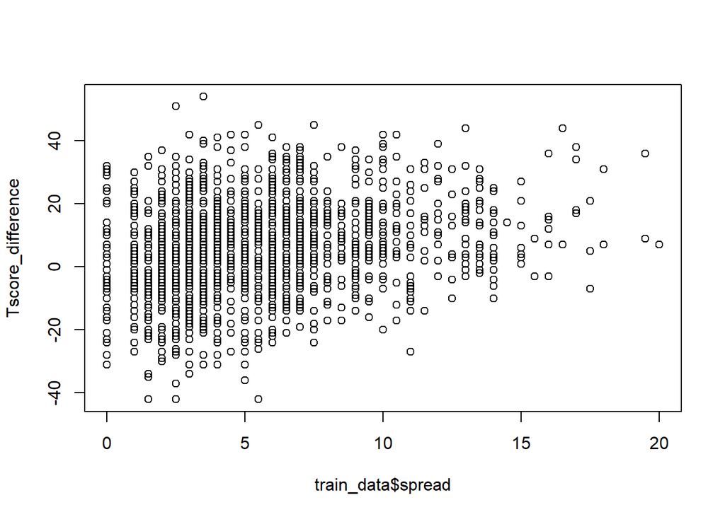

```r
plot(train_data$spread,Tscore_difference)
```

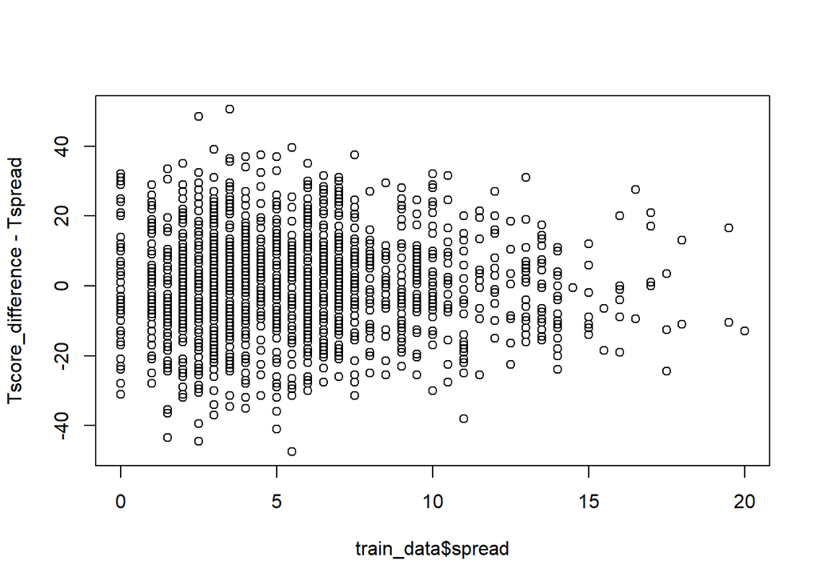

```r
plot(train_data$spread,Tscore_difference-Tspread)
```

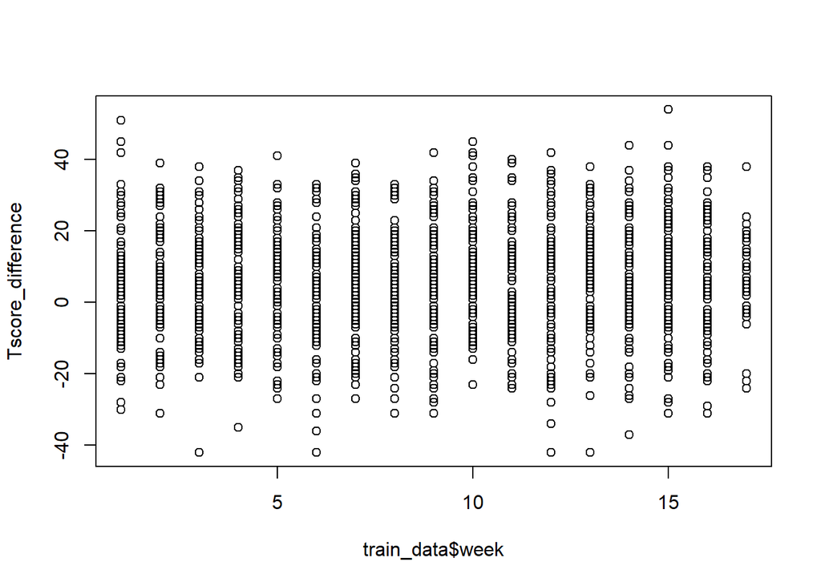

```r
plot(train_data$week,Tscore_difference)
```

##Model 1

```r
stan_data <- list(
  n = length(Tscore_difference),
  y = Tscore_difference,
  Tspread = Tspread
)

stan_code_model1 <- "
data {
  int<lower=0> n;
  vector[n] y;
  vector[n] Tspread;
}

parameters {
  real mu;
  real beta0;
  real<lower=0> sigma;
}

model {
  mu ~ normal(0, 10);
  beta0 ~ normal(0, 10);
  sigma ~ normal(0, 10);

  y ~ normal(mu + beta0 * Tspread, sigma);
}
generated quantities {
  vector[n] log_lik;

  for (i in 1:n) {
    log_lik[i] = normal_lpdf(y[i] | Tspread[i] * beta0 + mu, sigma);
  }
}

"

model_model1 <- stan_model(model_code = stan_code_model1)

fit_model1 <- sampling(model_model1, data = stan_data, chains = 4, iter = 2000)

print(fit_model1, pars=c("mu","beta0","sigma"),include=T)
```

```
## Inference for Stan model: anon_model.
## 4 chains, each with iter=2000; warmup=1000; thin=1;
## post-warmup draws per chain=1000, total post-warmup draws=4000.
##
##        mean se_mean   sd  2.5%   25%   50%   75% 97.5% n_eff Rhat
## mu     0.09    0.01 0.57 -1.03 -0.30  0.10  0.49  1.21  1775    1
## beta0  1.04    0.00 0.09  0.87  0.98  1.04  1.10  1.23  1679    1
## sigma 13.65    0.00 0.22 13.24 13.50 13.64 13.79 14.08  2551    1
##
## Samples were drawn using NUTS(diag_e) at Wed Nov  8 13:30:51 2023.
## For each parameter, n_eff is a crude measure of effective sample size,
## and Rhat is the potential scale reduction factor on split chains (at
## convergence, Rhat=1).
```

##Model 2

```r
stan_data_model2 <- list(
  n = length(Tscore_difference),
  y = Tscore_difference,
  Tspread = Tspread,
  Thome = train_data$home
)

stan_code_model2 <- "
data {
  int<lower=0> n;
  vector[n] y;
  vector[n] Tspread;
  vector[n] Thome;
}

parameters {
  real mu;
  real beta0;
  real beta1;  // New parameter for the home variable
  real<lower=0> sigma;
}

model {
  mu ~ normal(0, 10);
  beta0 ~ normal(0, 10);
  beta1 ~ normal(0, 10);
  sigma ~ normal(0, 10);
  y ~ normal(mu + beta0 * Tspread+ beta1 * Thome, sigma);
}
generated quantities {
  vector[n] log_lik;

  for (i in 1:n) {
    log_lik[i] = normal_lpdf(y[i] | Tspread[i] * beta0+Thome[i]*beta1 + mu, sigma);
  }
}
"
model_model2 <- stan_model(model_code = stan_code_model2)


fit_model2 <- sampling(model_model2, data = stan_data_model2, chains = 4, iter = 2000)


print(fit_model2, pars=c("mu","beta0","beta1","sigma"),include=T)
```

```
## Inference for Stan model: anon_model.
## 4 chains, each with iter=2000; warmup=1000; thin=1;
## post-warmup draws per chain=1000, total post-warmup draws=4000.
##
##        mean se_mean   sd  2.5%   25%   50%   75% 97.5% n_eff Rhat
## mu    -0.50    0.01 0.66 -1.80 -0.95 -0.50 -0.06  0.79  2397    1
## beta0  1.01    0.00 0.09  0.83  0.95  1.01  1.07  1.19  2593    1
## beta1  1.15    0.01 0.68 -0.23  0.72  1.18  1.60  2.44  2427    1
## sigma 13.64    0.00 0.22 13.22 13.49 13.63 13.78 14.08  3118    1
##
## Samples were drawn using NUTS(diag_e) at Wed Nov  8 13:32:08 2023.
## For each parameter, n_eff is a crude measure of effective sample size,
## and Rhat is the potential scale reduction factor on split chains (at
## convergence, Rhat=1).
```

##Model 3

```r
stan_data_model3 <- list(
  n = length(Tscore_difference),
  y = Tscore_difference,
  Tspread = Tspread,
  Thome = train_data$home,
  Tweek = train_data$week
)

stan_code_model3 <- "
data {
  int<lower=0> n;
  vector[n] y;
  vector[n] Tspread;
  vector[n] Thome;
  vector[n] Tweek;  // Include the week variable
}

parameters {
  real mu;
  real beta0;
  real beta1;
  real beta2;
  real<lower=0> sigma;
}

model {
  mu ~ normal(0, 10);
  beta0 ~ normal(0, 10);
  beta1 ~ normal(0, 10);
   beta2 ~ normal(0, 10);
  sigma ~ normal(0, 10);
  y ~ normal(mu + beta0 * Tspread + beta1 * Thome+beta2*Tweek, sigma);
}
generated quantities {
  vector[n] log_lik;

  for (i in 1:n) {
    log_lik[i] = normal_lpdf(y[i] | Tspread[i] * beta0+Thome[i]*beta1 +Tweek[i]*beta2 + mu, sigma);
  }
}

"

model_model3 <- stan_model(model_code = stan_code_model3)

fit_model3 <- sampling(model_model3, data = stan_data_model3, chains = 4, iter = 2000)

print(fit_model3, pars=c("mu","beta0","beta1","beta2","sigma"),include=T)
```

```
## Inference for Stan model: anon_model.
## 4 chains, each with iter=2000; warmup=1000; thin=1;
## post-warmup draws per chain=1000, total post-warmup draws=4000.
##
##        mean se_mean   sd  2.5%   25%   50%   75% 97.5% n_eff Rhat
## mu    -0.68    0.02 0.85 -2.34 -1.27 -0.69 -0.13  1.02  2798    1
## beta0  1.01    0.00 0.09  0.83  0.95  1.01  1.07  1.19  3711    1
## beta1  1.17    0.01 0.66 -0.11  0.73  1.18  1.61  2.48  3690    1
## beta2  0.02    0.00 0.07 -0.11 -0.02  0.02  0.06  0.15  3311    1
## sigma 13.64    0.00 0.21 13.23 13.50 13.64 13.79 14.07  4300    1
##
## Samples were drawn using NUTS(diag_e) at Wed Nov  8 13:33:21 2023.
## For each parameter, n_eff is a crude measure of effective sample size,
## and Rhat is the potential scale reduction factor on split chains (at
## convergence, Rhat=1).
```

##Model Comparison: The Case Where Model 1 2, and 3 Are Compared Below we are going to compare Models 1, 2 and 3 using WAICC and LOOIC and see which is the best.

```r
# Calculate log-likelihood for Models 1, 2 and 3
log_lik_model1 <- extract_log_lik(fit_model1)
log_lik_model2 <- extract_log_lik(fit_model2)
log_lik_model3 <- extract_log_lik(fit_model3)

# Calculate WAIC for Models 1, 2 and 3
waic_model1 <- waic(log_lik_model1)
waic_model2 <- waic(log_lik_model2)
waic_model3 <- waic(log_lik_model3)

# Compare WAIC values
waic_comparison <- loo_compare(list(waic_model1, waic_model2, waic_model3))

# Calculate LOOIC for Models 1, 2 and 3
loo_model1 <- loo(log_lik_model1)
loo_model2 <- loo(log_lik_model2)
loo_model3 <- loo(log_lik_model3)
# Compare LOOIC values
loo_comparison <- loo_compare(list(loo_model1, loo_model2, loo_model3))

# Access the WAIC and LOOIC comparisons
print(waic_comparison)
```

```
##        elpd_diff se_diff
## model2  0.0       0.0
## model1 -0.5       1.8
## model3 -0.8       0.3
```

```r
print(loo_comparison)
```

```
##        elpd_diff se_diff
## model2  0.0       0.0
## model1 -0.5       1.8
## model3 -0.8       0.3
```

```r
# Extract parameter samples from Model 1
samples_model1 <- rstan::extract(fit_model1)

# Initialize a matrix to store predicted values for Model 1
predicted_y_model1 <- matrix(NA, nrow = nrow(test_data), ncol = length(samples_model1$lp__))

# Loop over each sample to generate predictions for Model 1
for (i in 1:length(samples_model1$lp__)) {
  # Generate noise (random values) based on the standard deviation (sigma) from the samples
  noise <- rnorm(n = nrow(test_data), mean = 0, sd = samples_model1$sigma[i])

  # Calculate predictions for Model 1 for each sample
  predicted_y_model1[, i] <- samples_model1$mu[i] + samples_model1$beta0[i] * test_data$spread + noise
}

# Calculate the mean prediction for each data point for Model 1
mean_prediction_model1 <- apply(predicted_y_model1, 1, mean)

# Calculate the Mean Squared Error (MSE) for Model 1
mse_model1 <- rowMeans((test_data$favorite-test_data$underdog - predicted_y_model1)^2)

# Calculate the average MSE for Model 1 across samples
average_mse_model1 <- mean(mse_model1)
print(average_mse_model1)
```

```
## [1] 385.3397
```

```r
# Extract parameter samples from Model 2
samples_model2 <- rstan::extract(fit_model2)

# Initialize a matrix to store predicted values for Model 2
predicted_y_model2 <- matrix(NA, nrow = nrow(test_data), ncol = length(samples_model2$lp__))

# Loop over each sample to generate predictions for Model 2
for (i in 1:length(samples_model2$lp__)) {
  # Generate noise (random values) based on the standard deviation (sigma) from the samples
  noise <- rnorm(n = nrow(test_data), mean = 0, sd = samples_model2$sigma[i])

  # Calculate predictions for Model 2 for each sample
  predicted_y_model2[, i] <- samples_model2$mu[i] + samples_model2$beta0[i] * test_data$spread + noise
}

# Calculate the mean prediction for each data point for Model 2
mean_prediction_model2 <- apply(predicted_y_model2, 1, mean)

# Calculate the Mean Squared Error (MSE) for Model 2
mse_model2 <- rowMeans(((test_data$favorite-test_data$underdog) - predicted_y_model2)^2)

# Calculate the average MSE for Model 2 across samples
average_mse_model2 <- mean(mse_model2)
print(average_mse_model2)
```

```
## [1] 383.7697
```

##Test with test data.

```r
# Extract parameter samples from Model 1
samples_model1 <- rstan::extract(fit_model1)

# Initialize a matrix to store predicted values for Model 1
predicted_y_model1 <- matrix(NA, nrow = nrow(test_data), ncol = length(samples_model1$lp__))

# Initialize variables to store results
mse_model1_values <- numeric()
coverage_model1_values <- numeric()

# Loop over each sample to generate predictions for Model 1
for (i in 1:length(samples_model1$lp__)) {
  # Generate noise (random values) based on the standard deviation (sigma) from the samples
  noise <- rnorm(n = nrow(test_data), mean = 0, sd = samples_model1$sigma[i])

  # Calculate predictions for Model 1 for each sample
  predicted_y_model1[, i] <- samples_model1$mu[i] + samples_model1$beta0[i] * test_data$spread + noise
}

# Calculate the mean prediction for each data point for Model 1
mean_prediction_model1 <- rowMeans(predicted_y_model1)

# Calculate the Mean Squared Error (MSE) for Model 1
mse_model1 <- mean((test_data$favorite - test_data$underdog - mean_prediction_model1)^2)

# Calculate the average MSE for Model 1 across samples
average_mse_model1 <- mean(mse_model1)

# Check prediction interval coverage for each sample
for (i in 1:nrow(test_data)) {
  actual_score_difference <- test_data$favorite[i] - test_data$underdog[i]
  lower_quantile_model1 <- quantile(predicted_y_model1[i, ], 0.025)
  upper_quantile_model1 <- quantile(predicted_y_model1[i, ], 0.975)

  coverage_model1 <- (actual_score_difference >= lower_quantile_model1) & (actual_score_difference <= upper_quantile_model1)
  coverage_model1_values <- c(coverage_model1_values, coverage_model1)
}

# Calculate the average prediction interval coverage for Model 1
average_coverage_model1 <- mean(coverage_model1_values)

# Print the results for Model 1
cat("Average MSE for Model 1: ", average_mse_model1, "\n")
```

```
## Average MSE for Model 1:  199.0804
```

```r
cat("Average Prediction Interval Coverage for Model 1: ", average_coverage_model1, "\n")
```

```
## Average Prediction Interval Coverage for Model 1:  0.9291667
```

##Copy of the above but for Model 2

```r
# Extract parameter samples from Model 2
samples_model2 <- rstan::extract(fit_model2)

# Initialize a matrix to store predicted values for Model 2
predicted_y_model2 <- matrix(NA, nrow = nrow(test_data), ncol = length(samples_model2$lp__))

# Initialize variables to store results for Model 2
mse_model2_values <- numeric()
coverage_model2_values <- numeric()

# Loop over each sample to generate predictions for Model 2
for (i in 1:length(samples_model2$lp__)) {
  # Generate noise (random values) based on the standard deviation (sigma) from the samples
  noise <- rnorm(n = nrow(test_data), mean = 0, sd = samples_model2$sigma[i])

  # Calculate predictions for Model 2 for each sample
  predicted_y_model2[, i] <- samples_model2$mu[i] + samples_model2$beta0[i] * test_data$spread + samples_model2$beta1[i] * test_data$home + noise
}

# Calculate the mean prediction for each data point for Model 2
mean_prediction_model2 <- rowMeans(predicted_y_model2)

# Calculate the Mean Squared Error (MSE) for Model 2
mse_model2 <- mean((test_data$favorite - test_data$underdog - mean_prediction_model2)^2)

# Calculate the average MSE for Model 2 across samples
average_mse_model2 <- mean(mse_model2)

# Check prediction interval coverage for each sample in Model 2
for (i in 1:nrow(test_data)) {
  lower_quantile_model2 <- quantile(predicted_y_model2[i, ], 0.025)
  upper_quantile_model2 <- quantile(predicted_y_model2[i, ], 0.975)

  coverage_model2 <- (test_data$favorite[i] - test_data$underdog[i] >= lower_quantile_model2) & (test_data$favorite[i] - test_data$underdog[i] <= upper_quantile_model2)
  coverage_model2_values <- c(coverage_model2_values, coverage_model2)
}

# Calculate the average prediction interval coverage for Model 2
average_coverage_model2 <- mean(coverage_model2_values)

# Print the results for Model 2
cat("Average MSE for Model 2: ", average_mse_model2, "\n")
```

```
## Average MSE for Model 2:  200.0496
```

```r
cat("Average Prediction Interval Coverage for Model 2: ", average_coverage_model2, "\n")
```

```
## Average Prediction Interval Coverage for Model 2:  0.9375
```

##Horizontal

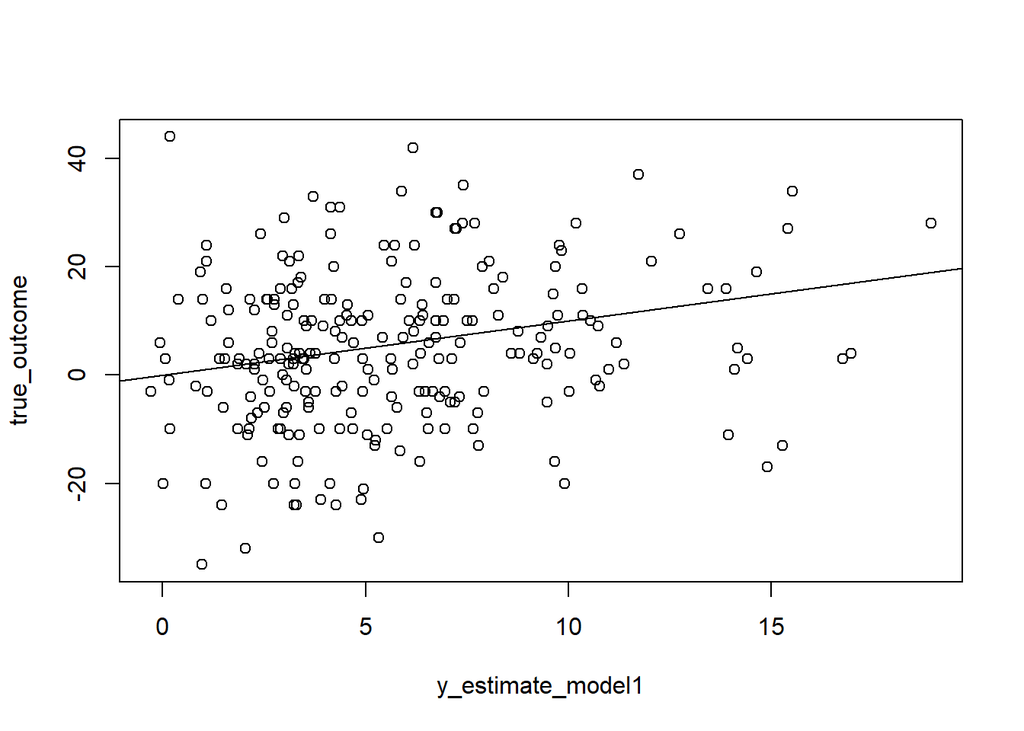

```r
true_outcome <- test_data$favorite-test_data$underdog
y_estimate_model1 <- apply(predicted_y_model1,1,mean)
y_estimate_model1 <- rowMeans(predicted_y_model1)
plot(y_estimate_model1 , true_outcome)
abline(0,1)
```

##Gambling Suggested By Yuan

```r
prob_estimate_model2 <- apply(predicted_y_model2,1,function(x) mean(x>0))
true_outcome <- test_data$favorite-test_data$underdog
win <- 1
loseORtie <- 3
strategy <- as.numeric(prob_estimate_model2 > loseORtie/(loseORtie+win))
income_vec <- ifelse(true_outcome[strategy==1]>0, 1, -3)
sum(income_vec)
```

```
## [1] 4
```